# K-Means Clustering on Synthetic Blob Data

This notebook demonstrates the `KMeans` clustering algorithm implemented in the `jiayi_ml` package.

The goal is to identify groups in unlabeled data using distance-based clustering.

This example emphasizes:

1. Unsupervised learning.
2. Cluster visualization.
3. The role of the number of clusters.
4. K-Means inertia.
5. The elbow method.
6. Sensitivity to cluster shape and initialization.
7. Interpretation of clustering results without using labels for training.

## 1. Problem Statement

K-Means is an unsupervised clustering algorithm.

Unlike supervised learning, clustering does not use target labels during fitting. The goal is to discover structure in the feature space.

K-Means tries to partition data into `k` clusters by minimizing the total squared distance between each point and its assigned cluster center.

The main question in this notebook is:

> Can K-Means recover meaningful cluster structure from unlabeled data?

A synthetic blob dataset is used because it allows clear visualization of the algorithm's strengths and limitations.

```python
from pathlib import Path
import sys

# Make the local package importable whether the notebook is run from the
# project root or from inside the examples directory.
current_path = Path.cwd().resolve()
for candidate in [current_path, *current_path.parents]:
    if (candidate / "src" / "jiayi_ml").exists():
        sys.path.insert(0, str(candidate / "src"))
        PROJECT_ROOT = candidate
        break

import numpy as np
import pandas as pd
import matplotlib.pyplot as plt

from sklearn.datasets import make_blobs

from jiayi_ml.preprocessing import StandardScaler
from jiayi_ml.unsupervised import KMeans

np.random.seed(438)
pd.set_option("display.precision", 4)
```

## 2. Generate Synthetic Blob Data

The dataset is generated with `sklearn.datasets.make_blobs`.

Although the generator provides true labels, these labels are not used during K-Means fitting. They are used only after clustering to help interpret whether the discovered clusters align with the known synthetic groups.

The data is suitable for K-Means because blob-shaped clusters are roughly spherical and separated in Euclidean space.

```python
X, true_labels = make_blobs(
    n_samples=450,
    centers=4,
    cluster_std=[0.8, 1.1, 0.7, 1.0],
    random_state=438,
)

df = pd.DataFrame(X, columns=["feature_1", "feature_2"])
df["true_group"] = true_labels

print("Feature matrix shape:", X.shape)
print("Number of synthetic groups:", len(np.unique(true_labels)))

df.head()
```

```
Feature matrix shape: (450, 2)
Number of synthetic groups: 4
```

|  | feature_1 | feature_2 | true_group |
| --- | --- | --- | --- |
| 0 | -0.8822 | 1.2211 | 3 |
| 1 | -6.3414 | 10.8712 | 0 |
| 2 | -1.2715 | 1.0732 | 2 |
| 3 | -0.7034 | 2.1258 | 3 |
| 4 | -8.5956 | 9.0665 | 0 |

## 3. Exploratory Visualization

Because this dataset has two features, we can directly visualize the samples.

The first plot shows the unlabeled data, which is the view available to K-Means. The second plot uses the synthetic labels only for interpretation.

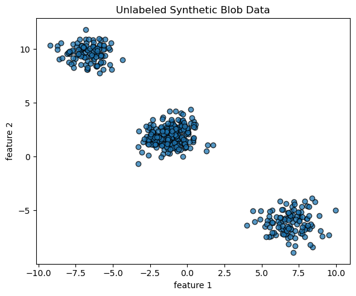

```python
plt.figure(figsize=(6, 5))
plt.scatter(X[:, 0], X[:, 1], alpha=0.75, edgecolors="k")
plt.xlabel("feature 1")
plt.ylabel("feature 2")
plt.title("Unlabeled Synthetic Blob Data")
plt.tight_layout()
plt.show()
```

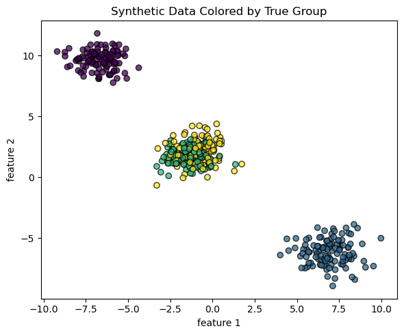

```python
plt.figure(figsize=(6, 5))
plt.scatter(X[:, 0], X[:, 1], c=true_labels, alpha=0.75, edgecolors="k")
plt.xlabel("feature 1")
plt.ylabel("feature 2")
plt.title("Synthetic Data Colored by True Group")
plt.tight_layout()
plt.show()
```

## 4. Standardization

K-Means relies on Euclidean distances. If features have very different scales, features with larger numeric ranges can dominate the clustering result.

Here, both features are generated on comparable scales, but we still standardize to demonstrate a consistent preprocessing workflow.

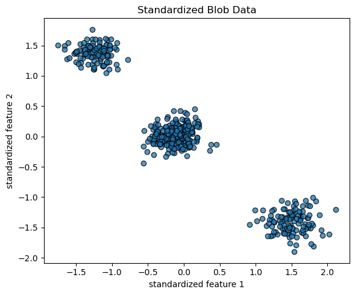

```python
scaler = StandardScaler()
X_scaled = scaler.fit_transform(X)

plt.figure(figsize=(6, 5))
plt.scatter(X_scaled[:, 0], X_scaled[:, 1], alpha=0.75, edgecolors="k")
plt.xlabel("standardized feature 1")
plt.ylabel("standardized feature 2")
plt.title("Standardized Blob Data")
plt.tight_layout()
plt.show()
```

## 5. Fit K-Means with the Correct Number of Clusters

We first fit K-Means with `n_clusters = 4`, matching the known number of synthetic centers.

The algorithm does not know the true labels. It only sees the feature matrix.

```python
model = KMeans(
    n_clusters=4,
    init="k-means++",
    n_init=10,
    max_iter=300,
    random_state=438,
)

cluster_labels = model.fit_predict(X_scaled)

print("Cluster centers shape:", model.cluster_centers_.shape)
print("Inertia:", model.inertia_)
print("Iterations for best run:", model.n_iter_)
print("Cluster counts:", np.bincount(cluster_labels))
```

```
Cluster centers shape: (4, 2)
Inertia: 22.45014490926228
Iterations for best run: 10
Cluster counts: [113 113 103 121]
```

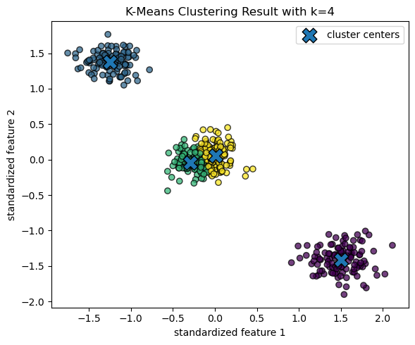

```python
plt.figure(figsize=(6, 5))
plt.scatter(X_scaled[:, 0], X_scaled[:, 1], c=cluster_labels, alpha=0.75, edgecolors="k")
plt.scatter(
    model.cluster_centers_[:, 0],
    model.cluster_centers_[:, 1],
    marker="X",
    s=220,
    edgecolors="k",
    label="cluster centers",
)
plt.xlabel("standardized feature 1")
plt.ylabel("standardized feature 2")
plt.title("K-Means Clustering Result with k=4")
plt.legend()
plt.tight_layout()
plt.show()
```

The cluster centers summarize the location of each group. Each sample is assigned to the nearest center.

For this blob-shaped dataset, K-Means is expected to perform well because the clusters are compact and approximately spherical.

## 6. Compare Cluster Labels with True Synthetic Groups

In real unsupervised learning, true labels are often unavailable. In this synthetic dataset, true labels are available only for evaluation and interpretation.

The contingency table below compares discovered clusters with true synthetic groups.

```python
comparison_df = pd.DataFrame(
    {
        "true_group": true_labels,
        "kmeans_cluster": cluster_labels,
    }
)

contingency_table = pd.crosstab(
    comparison_df["true_group"],
    comparison_df["kmeans_cluster"],
    rownames=["true group"],
    colnames=["K-Means cluster"],
)

contingency_table
```

| K-Means cluster true group | 0 | 1 | 2 | 3 |
| --- | --- | --- | --- | --- |
| 0 | 0 | 113 | 0 | 0 |
| 1 | 113 | 0 | 0 | 0 |
| 2 | 0 | 0 | 75 | 37 |
| 3 | 0 | 0 | 28 | 84 |

The contingency table shows that K-Means clearly separates two of the synthetic groups, but the other two groups are partially mixed across two clusters. This means the clustering result captures much of the blob structure but does not perfectly recover all four true generating groups. This is a useful result because it shows both the strength and limitation of K-Means: it performs well when groups are compact and separated, but nearby or overlapping groups can still be split or mixed. The numeric cluster labels are arbitrary, so cluster 0 does not need to correspond to true group 0. In this result, true groups 0 and 1 are each cleanly assigned to a single cluster. However, true groups 2 and 3 are split across two clusters, indicating that K-Means partially mixes these two nearby groups. This is a realistic outcome: K-Means performs well when groups are compact and well separated, but nearby or overlapping groups can still be mixed.

## 7. Choosing k with the Elbow Method

In real clustering problems, the correct number of clusters is usually unknown.

The elbow method fits K-Means for several values of `k` and plots inertia. Inertia decreases as `k` increases, because more clusters can always reduce within-cluster distances.

The goal is to look for a point where the improvement begins to slow down.

```python
k_values = list(range(1, 11))
inertias = []

for k in k_values:
    kmeans = KMeans(
        n_clusters=k,
        init="k-means++",
        n_init=10,
        random_state=438,
    )
    kmeans.fit(X_scaled)
    inertias.append(kmeans.inertia_)

elbow_df = pd.DataFrame(
    {
        "k": k_values,
        "inertia": inertias,
    }
)

elbow_df
```

|  | k | inertia |
| --- | --- | --- |
| 0 | 1 | 900.0000 |
| 1 | 2 | 261.5200 |
| 2 | 3 | 27.9470 |
| 3 | 4 | 22.4501 |
| 4 | 5 | 19.0785 |
| 5 | 6 | 16.5936 |
| 6 | 7 | 14.1259 |
| 7 | 8 | 12.3002 |
| 8 | 9 | 11.2452 |
| 9 | 10 | 10.2379 |

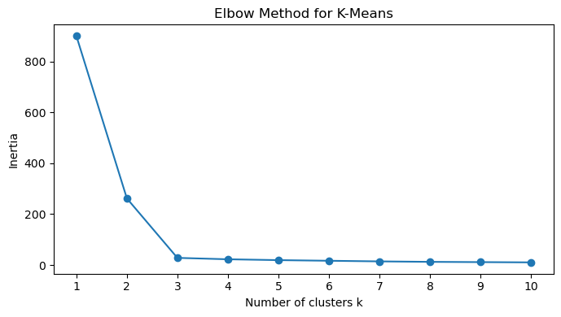

```python
plt.figure(figsize=(7, 4))
plt.plot(elbow_df["k"], elbow_df["inertia"], marker="o")
plt.xlabel("Number of clusters k")
plt.ylabel("Inertia")
plt.title("Elbow Method for K-Means")
plt.xticks(k_values)
plt.tight_layout()
plt.show()
```

Looking at the inertia values, the largest drop occurs from k=2 to k=3 (261.52 to 27.95), and the improvement becomes much smaller after that (k=3 to k=4: 27.95 to 22.45, and continuing to decrease slowly). The elbow therefore appears around k=3 rather than clearly at k=4, even though the data was generated from four centers. This happens because two of the synthetic groups overlap substantially, making it difficult for the inertia curve alone to pinpoint the true number of clusters. The elbow method is useful but subjective. It should be combined with domain knowledge and visualization when possible, and it may not always recover the exact number of generating groups when clusters overlap.

## 8. Effect of Choosing the Wrong Number of Clusters

K-Means requires the user to specify `k`. If `k` is too small, distinct groups may be merged. If `k` is too large, natural groups may be split into artificial subclusters.

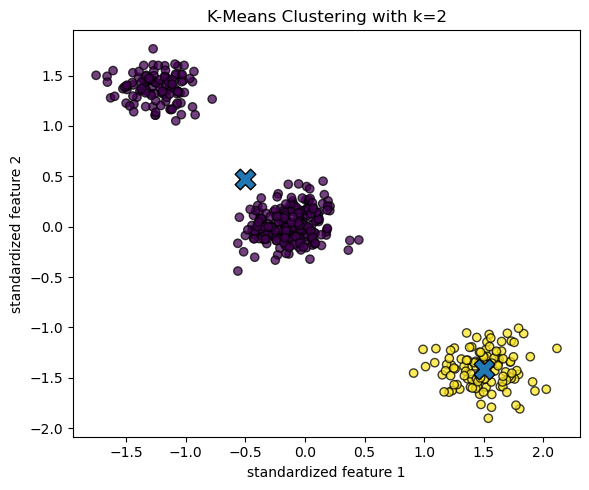

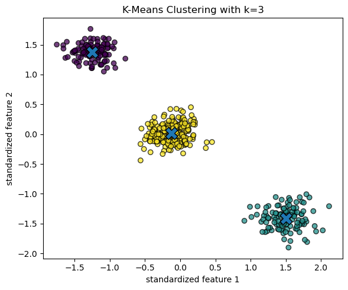

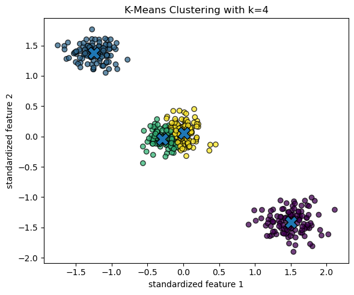

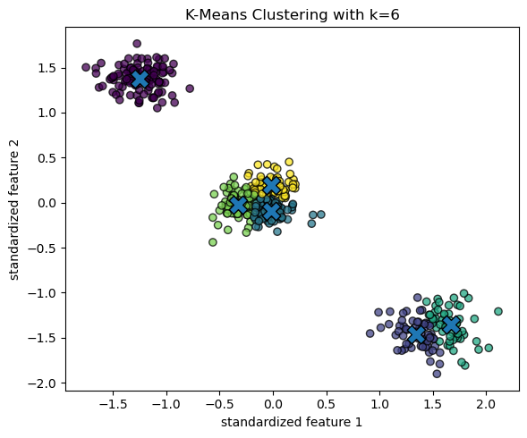

```python
for k in [2, 3, 4, 6]:
    kmeans = KMeans(
        n_clusters=k,
        init="k-means++",
        n_init=10,
        random_state=438,
    )
    labels = kmeans.fit_predict(X_scaled)

    plt.figure(figsize=(6, 5))
    plt.scatter(X_scaled[:, 0], X_scaled[:, 1], c=labels, alpha=0.75, edgecolors="k")
    plt.scatter(
        kmeans.cluster_centers_[:, 0],
        kmeans.cluster_centers_[:, 1],
        marker="X",
        s=220,
        edgecolors="k",
    )
    plt.xlabel("standardized feature 1")
    plt.ylabel("standardized feature 2")
    plt.title(f"K-Means Clustering with k={k}")
    plt.tight_layout()
    plt.show()
```

This comparison illustrates that K-Means will always return the requested number of clusters, even if that number does not reflect the natural structure of the data. This is both a strength and a limitation.

## 9. Sensitivity to Cluster Shape

K-Means works best when clusters are:

- roughly spherical
- similarly sized
- separated by Euclidean distance
- not strongly affected by outliers

When clusters are non-spherical, have different densities, or contain noise, methods such as DBSCAN may be more appropriate. This limitation is explored in the DBSCAN notebook.

## 10. Interpretation

K-Means captures the main structure of this synthetic blob dataset, but it does not perfectly recover all four true generating groups. Two groups are separated clearly, while two nearby groups are partially mixed. This result is realistic and useful: K-Means can provide meaningful distance-based groupings, but its output should not be treated as ground truth without additional validation.

The cluster centers provide a compact summary of the data. However, the clusters should be interpreted as distance-based groups, not necessarily as meaningful real-world categories unless supported by domain knowledge.

## 11. Limitations

This analysis has several limitations:

1. The dataset is synthetic and cleaner than many real datasets.
2. K-Means requires the number of clusters to be specified in advance.
3. The algorithm assumes Euclidean distance is meaningful.
4. It works best for compact, spherical clusters.
5. It can be sensitive to initialization, although k-means++ and multiple initializations reduce this issue.
6. It does not naturally identify noise points.
7. Cluster labels are arbitrary and require interpretation.

A stronger real-world analysis would combine clustering with domain knowledge, stability checks, and external validation if labels are available.

## 12. Conclusion

This notebook demonstrated K-Means clustering using the custom `KMeans` implementation from `jiayi_ml`.

Key takeaways:

- K-Means is an unsupervised clustering algorithm.
- It assigns points to the nearest cluster center.
- Inertia measures within-cluster compactness.
- The elbow method can help choose the number of clusters.
- K-Means performs well on compact blob-shaped clusters.
- K-Means can perform poorly when cluster shapes are non-spherical or when noise is present.